# Statistical Rethinking: Chapter 5

# Multivariate Linear Models

## Spurious association

Does marriage cause divorce?

```r
# load data
library(rethinking)
data(WaffleDivorce)
d <- WaffleDivorce
# standardize predictor
d$MedianAgeMarriage.s <- (d$MedianAgeMarriage - mean(d$MedianAgeMarriage)) / sd(d$MedianAgeMarriage)
# fit the model
m5.1 <- map(
  alist(Divorce ~ dnorm(mu, sigma),
        mu <- a + bA * MedianAgeMarriage.s,
        a ~ dnorm(10, 10),
        bA ~ dnorm(0, 1),
        sigma ~ dunif(0, 10)),
  data = d
)
# results
precis(m5.1)
```

|  | Mean | StdDev | 5.5% | 94.5% |
| --- | --- | --- | --- | --- |
| a | 9.69 | 0.20 | 9.36 | 10.01 |
| bA | -1.04 | 0.20 | -1.37 | -0.72 |
| sigma | 1.45 | 0.14 | 1.22 | 1.68 |

```r
# compute the percentile interval of the mean
MAM.seq <- seq(from = 3, to = 3.5, length.out = 30)
mu <- link(m5.1, data = data.frame(MedianAgeMarriage.s = MAM.seq))
```

```
[ 100 / 1000 ]
[ 200 / 1000 ]
[ 300 / 1000 ]
[ 400 / 1000 ]
[ 500 / 1000 ]
[ 600 / 1000 ]
[ 700 / 1000 ]
[ 800 / 1000 ]
[ 900 / 1000 ]
[ 1000 / 1000 ]
```

```r
mu.PI <- apply(mu, 2, PI)
# plot
plot(Divorce ~ MedianAgeMarriage.s, data = d, col = rangi2)
abline(m5.1)
```

```
only using the first two of 3 regression coefficients
```

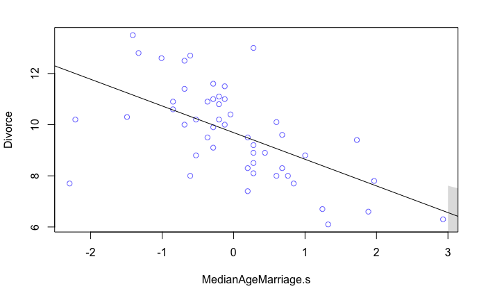

```r
shade(mu.PI, MAM.seq)
```

```r
# standardize predictor
d$Marriage.s <- (d$Marriage - mean(d$Marriage)) / sd(d$Marriage)
# fit the model
m5.2 <- map(
  alist(Divorce ~ dnorm(mu, sigma),
        mu <- a + bR * Marriage.s,
        a ~ dnorm(10, 10),
        bR ~ dnorm(0, 1),
        sigma ~ dunif(0, 10)),
  data = d
)
# results
precis(m5.2)
```

|  | Mean | StdDev | 5.5% | 94.5% |
| --- | --- | --- | --- | --- |
| a | 9.69 | 0.24 | 9.31 | 10.07 |
| bR | 0.64 | 0.23 | 0.27 | 1.02 |
| sigma | 1.67 | 0.17 | 1.40 | 1.94 |

```r
# compute the percentile interval of the mean
MAM.seq <- seq(from = 3, to = 3.5, length.out = 30)
mu <- link(m5.2, data = data.frame(Marriage.s = MAM.seq))
```

```
[ 100 / 1000 ]
[ 200 / 1000 ]
[ 300 / 1000 ]
[ 400 / 1000 ]
[ 500 / 1000 ]
[ 600 / 1000 ]
[ 700 / 1000 ]
[ 800 / 1000 ]
[ 900 / 1000 ]
[ 1000 / 1000 ]
```

```r
mu.PI <- apply(mu, 2, PI)
# plot
plot(Divorce ~ Marriage.s, data = d, col = rangi2)
abline(m5.2)
```

```
only using the first two of 3 regression coefficients
```

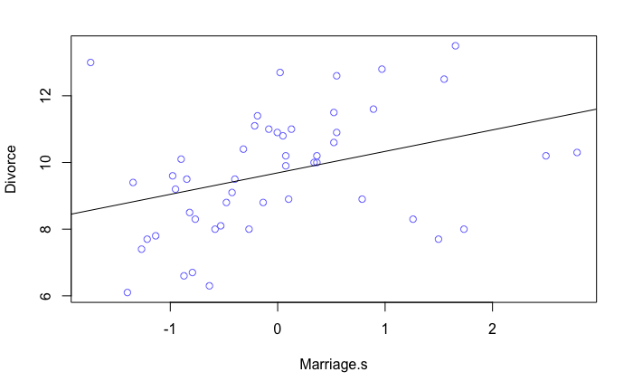

```r
shade(mu.PI, MAM.seq)
```

Now let’s add both variables:

```r
# fit the model
m5.3 <- map(
  alist(Divorce ~ dnorm(mu, sigma),
        mu <- a + bA * MedianAgeMarriage.s + bR * Marriage.s,
        a ~ dnorm(10, 10),
        bA ~ dnorm(0, 1),
        bR ~ dnorm(0, 1),
        sigma ~ dunif(0, 10)),
  data = d
)
# results
precis(m5.3)
```

|  | Mean | StdDev | 5.5% | 94.5% |
| --- | --- | --- | --- | --- |
| a | 9.69 | 0.20 | 9.36 | 10.01 |
| bA | -1.13 | 0.28 | -1.58 | -0.69 |
| bR | -0.13 | 0.28 | -0.58 | 0.31 |
| sigma | 1.44 | 0.14 | 1.21 | 1.67 |

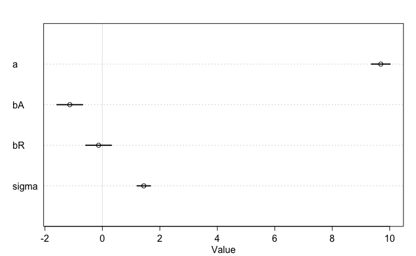

```r
plot(precis(m5.3))
```

```r
# compute the percentile interval of the mean
MAM.seq <- seq(from = 3, to = 3.5, length.out = 30)
mu <- link(m5.2, data = data.frame(Marriage.s = MAM.seq))
```

```
[ 100 / 1000 ]
[ 200 / 1000 ]
[ 300 / 1000 ]
[ 400 / 1000 ]
[ 500 / 1000 ]
[ 600 / 1000 ]
[ 700 / 1000 ]
[ 800 / 1000 ]
[ 900 / 1000 ]
[ 1000 / 1000 ]
```

```r
mu.PI <- apply(mu, 2, PI)
# plot
plot(Divorce ~ Marriage.s, data = d, col = rangi2)
abline(m5.2)
```

```
only using the first two of 3 regression coefficients
```

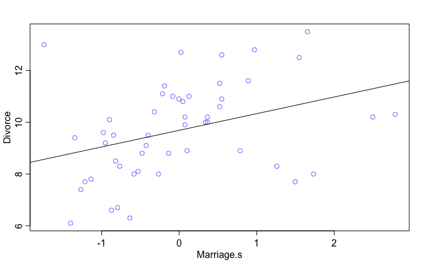

```r
shade(mu.PI, MAM.seq)
```

### Plotting to intrepret linear regression

We will cover three techniques:

1. Predictor residual plots: These show the outcome against residual predictor values
2. Counterfactual plots: These show implied predictions for imaginary experiments in which the different variables can be changed independently of on another
3. Posterior prediction plots: These show model-based predictions against raw data, or otherwise display the error in prediction

#### Predictor residual plots

```r
m5.4 <- map(
  alist(Marriage.s ~ dnorm(mu, sigma),
        mu <- a + b * MedianAgeMarriage.s,
        a ~ dnorm(0, 10),
        b ~ dnorm(0, 1),
        sigma ~ dunif(0, 10)),
  data = d
)
# now calculate residuals by subtracting observed marriage rate in each state
# from the predicted rate
# compute expected value at MAP for each state
mu <- coef(m5.4)["a"] + coef(m5.4)["b"] * d$MedianAgeMarriage.s
# compute residual for each state
m.resid <- d$Marriage.s - mu
# plot
plot(Marriage.s ~ MedianAgeMarriage.s, d, col = rangi2)
abline(m5.4)
```

```
only using the first two of 3 regression coefficients
```

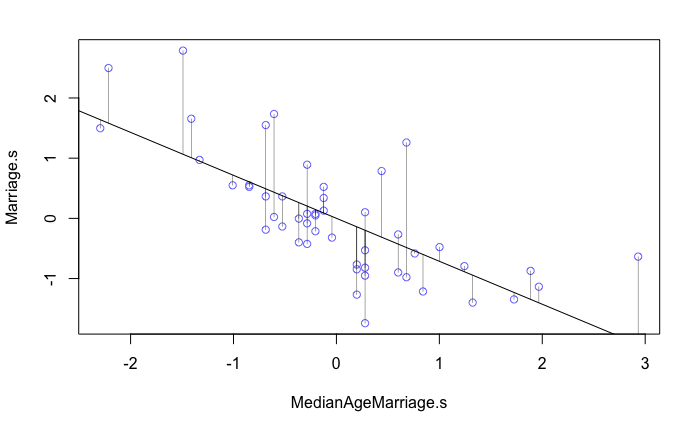

```r
## loop over states
for (i in 1:length(m.resid)) {
  x <- d$MedianAgeMarriage.s[i] # x location of line segment
  y <- d$Marriage.s[i] # observed endpoint of line segment

  # draw line segment
  lines(c(x, x), c(mu[i], y), lwd = 0.5, col = col.alpha("black", 0.7))
}
```

#### Counterfactual plots

```r
# prepare new counterfactual data
A.avg <- mean(d$MedianAgeMarriage.s)
R.seq <- seq(from = -3, to = 3, length.out = 30)
pred.data <- data.frame(Marriage.s = R.seq,
                        MedianAgeMarriage.s = A.avg)
# compute counterfactual mean divorce (mu)
mu <- link(m5.3, data = pred.data)
```

```
[ 100 / 1000 ]
[ 200 / 1000 ]
[ 300 / 1000 ]
[ 400 / 1000 ]
[ 500 / 1000 ]
[ 600 / 1000 ]
[ 700 / 1000 ]
[ 800 / 1000 ]
[ 900 / 1000 ]
[ 1000 / 1000 ]
```

```r
mu.mean <- apply(mu, 2, mean)
mu.PI <- apply(mu, 2, PI)
# simulate counterfactual divorce outcomes
R.sim <- sim(m5.3, data = pred.data, n = 10000)
```

```
[ 1000 / 10000 ]
[ 2000 / 10000 ]
[ 3000 / 10000 ]
[ 4000 / 10000 ]
[ 5000 / 10000 ]
[ 6000 / 10000 ]
[ 7000 / 10000 ]
[ 8000 / 10000 ]
[ 9000 / 10000 ]
[ 10000 / 10000 ]
```

```r
R.PI <- apply(R.sim, 2, PI)
# display predictions, hiding raw data with type = "n"
plot(Divorce ~ Marriage.s, data = d, type = "n")
mtext("MedianAgeMarriage.s = 0")
```

```r
lines(R.seq, mu.mean)
shade(mu.PI, R.seq)
```

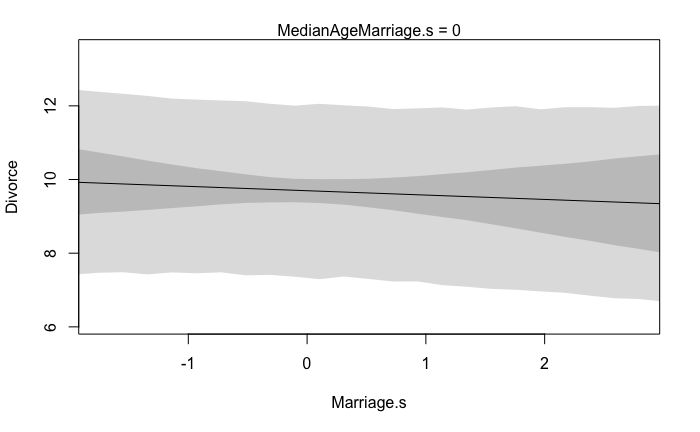

```r
shade(R.PI, R.seq)
```

#### Posterior prediction plots

Useful for checking the model fit and where the model fails.

```r
# call link without specifying new data so it uses orignial data
mu <- link(m5.3)
```

```
[ 100 / 1000 ]
[ 200 / 1000 ]
[ 300 / 1000 ]
[ 400 / 1000 ]
[ 500 / 1000 ]
[ 600 / 1000 ]
[ 700 / 1000 ]
[ 800 / 1000 ]
[ 900 / 1000 ]
[ 1000 / 1000 ]
```

```r
# summarize samples across cases
mu.mean <- apply(mu, 2, mean)
mu.PI <- apply(mu, 2, PI)
# simulate observations
# again no new data, so it uses original data
divorce.sim <- sim(m5.3, n = 10000)
```

```
[ 1000 / 10000 ]
[ 2000 / 10000 ]
[ 3000 / 10000 ]
[ 4000 / 10000 ]
[ 5000 / 10000 ]
[ 6000 / 10000 ]
[ 7000 / 10000 ]
[ 8000 / 10000 ]
[ 9000 / 10000 ]
[ 10000 / 10000 ]
```

```r
divorce.PI <- apply(divorce.sim, 2, PI)
# plot predicted values against observed
plot(mu.mean ~ d$Divorce, col = rangi2, ylim = range(mu.PI),
     xlab = "Observed Divorce", ylab = "Predicted Divorce")
abline(a = 0, b = 1, lty = 2)
```

```
integer(0)
```

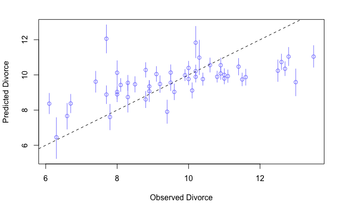

```r
for (i in 1:nrow(d)) {
  lines(rep(d$Divorce[i], 2), c(mu.PI[1, i], mu.PI[2, i]), col = rangi2)
}
identify(x = d$Divorce, y = mu.mean, labels = d$Loc, cex = 0.8)
```

Residual plot:

```r
# compute residuals
divorce.resid <- d$Divorce - mu.mean
# get ordering by divorce rate
o <- order(divorce.resid)
# plot
dotchart(divorce.resid[o], labels = d$Loc[o], xlim = c(-6, 5), cex = 0.6)
abline(v = 0, col = col.alpha("black", 0.2))
```

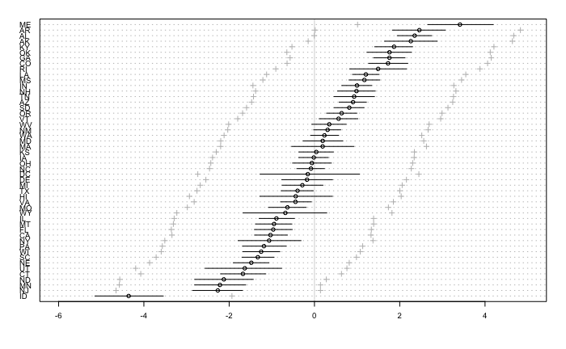

```r
for (i in 1:nrow(d)) {
  j <- o[i] # which state order
  lines(d$Divorce[j] - c(mu.PI[1, j], mu.PI[2, j]), rep(i, 2))
  points(d$Divorce[j] - c(divorce.PI[1, j], divorce.PI[2, j]), rep(i, 2),
         pch = 3, cex = 0.6, col = "gray")
}
```

## Masked Relationship

```r
library(rethinking)
data(milk)
d <- milk
str(d)
```

```
'data.frame':   29 obs. of  8 variables:
 $ clade         : Factor w/ 4 levels "Ape","New World Monkey",..: 4 4 4 4 4 2 2 2 2 2 ...
 $ species       : Factor w/ 29 levels "A palliata","Alouatta seniculus",..: 11 8 9 10 16 2 1 6 28 27 ...
 $ kcal.per.g    : num  0.49 0.51 0.46 0.48 0.6 0.47 0.56 0.89 0.91 0.92 ...
 $ perc.fat      : num  16.6 19.3 14.1 14.9 27.3 ...
 $ perc.protein  : num  15.4 16.9 16.9 13.2 19.5 ...
 $ perc.lactose  : num  68 63.8 69 71.9 53.2 ...
 $ mass          : num  1.95 2.09 2.51 1.62 2.19 5.25 5.37 2.51 0.71 0.68 ...
 $ neocortex.perc: num  55.2 NA NA NA NA ...
```

Consider a bivariate regression between kilocarories and neocotrex percent:

```r
m5.5 <- map(
  alist(kcal.per.g ~ dnorm(mu, sigma),
        mu <- a + bn * neocortex.perc,
        a ~ dnorm(0, 100),
        bn ~ dnorm(0, 1),
        sigma ~ dunif(0, 1)),
  data = d
)
```

```
Error in map(alist(kcal.per.g ~ dnorm(mu, sigma), mu <- a + bn * neocortex.perc,  :
The start values for the parameters were invalid. This could be caused by missing values (NA) in the data or by start values outside the parameter constraints. If there are no NA values in the data, try using explicit start values.
```

This error arrises because of the missing values in `neocortex.perc`

```r
d$neocortex.perc
```

```
 [1] 55.16    NA    NA    NA    NA 64.54 64.54 67.64    NA 68.85 58.85 61.69 60.32    NA    NA 69.97    NA 70.41    NA 73.40    NA 67.53    NA 71.26 72.60    NA 70.24 76.30 75.49
```

```r
# drop missing values
dcc <- d[complete.cases(d), ]
# re-estimate the model
m5.5 <- map(
  alist(kcal.per.g ~ dnorm(mu, sigma),
        mu <- a + bn * neocortex.perc,
        a ~ dnorm(0, 100),
        bn ~ dnorm(0, 1),
        sigma ~ dunif(0, 1)),
  data = dcc
)
# results
precis(m5.5, digits = 3)
```

|  | Mean | StdDev | 5.5% | 94.5% |
| --- | --- | --- | --- | --- |
| a | 0.353 | 0.471 | -0.399 | 1.106 |
| bn | 0.005 | 0.007 | -0.007 | 0.016 |
| sigma | 0.166 | 0.028 | 0.120 | 0.211 |

Plot the predicted mean and 89% interval for the mean:

```r
np.seq <- 0:100
pred.data <- data.frame(neocortex.perc = np.seq)
mu <- link(m5.5, data = pred.data, n = 10000)
```

```
[ 1000 / 10000 ]
[ 2000 / 10000 ]
[ 3000 / 10000 ]
[ 4000 / 10000 ]
[ 5000 / 10000 ]
[ 6000 / 10000 ]
[ 7000 / 10000 ]
[ 8000 / 10000 ]
[ 9000 / 10000 ]
[ 10000 / 10000 ]
```

```r
mu.mean <- apply(mu, 2, mean)
mu.PI <- apply(mu, 2, PI)
plot(kcal.per.g ~ neocortex.perc, data = dcc, col = rangi2)
lines(np.seq, mu.mean)
```

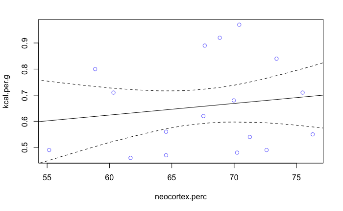

```r
lines(np.seq, mu.PI[1, ], lty = 2)
lines(np.seq, mu.PI[2, ], lty = 2)
```

Now let’s add in the natural log of `mass`:

```r
dcc$log.mass = log(dcc$mass)
# fit the model
m5.6 <- map(
  alist(kcal.per.g ~ dnorm(mu, sigma),
        mu <- a + bm * log.mass,
        a ~ dnorm(0, 100),
        bm ~ dnorm(0, 1),
        sigma ~ dunif(0, 1)),
  data = dcc
)
precis(m5.6)
```

|  | Mean | StdDev | 5.5% | 94.5% |
| --- | --- | --- | --- | --- |
| a | 0.71 | 0.05 | 0.63 | 0.78 |
| bm | -0.03 | 0.02 | -0.06 | 0.00 |
| sigma | 0.16 | 0.03 | 0.11 | 0.20 |

```r
# plot
mp.seq <- 0:100
pred.data <- data.frame(log.mass = mp.seq)
mu <- link(m5.6, data = pred.data, n = 10000)
```

```
[ 1000 / 10000 ]
[ 2000 / 10000 ]
[ 3000 / 10000 ]
[ 4000 / 10000 ]
[ 5000 / 10000 ]
[ 6000 / 10000 ]
[ 7000 / 10000 ]
[ 8000 / 10000 ]
[ 9000 / 10000 ]
[ 10000 / 10000 ]
```

```r
mu.mean <- apply(mu, 2, mean)
mu.PI <- apply(mu, 2, PI)
plot(kcal.per.g ~ log.mass, data = dcc, col = rangi2)
lines(mp.seq, mu.mean)
```

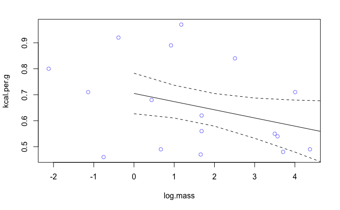

```r
lines(mp.seq, mu.PI[1, ], lty = 2)
lines(mp.seq, mu.PI[2, ], lty = 2)
```

Now both variables together:

```r
# fit the model
m5.7 <- map(
  alist(kcal.per.g ~ dnorm(mu, sigma),
        mu <- a + bn * neocortex.perc + bm * log.mass,
        a ~ dnorm(0, 100),
        bn ~ dnorm(0, 1),
        bm ~ dnorm(0, 1),
        sigma ~ dunif(0, 1)),
  data = dcc
)
precis(m5.7)
```

|  | Mean | StdDev | 5.5% | 94.5% |
| --- | --- | --- | --- | --- |
| a | -1.08 | 0.47 | -1.83 | -0.34 |
| bn | 0.03 | 0.01 | 0.02 | 0.04 |
| bm | -0.10 | 0.02 | -0.13 | -0.06 |
| sigma | 0.11 | 0.02 | 0.08 | 0.15 |

```r
# plot
mean.log.mass <- mean(log(dcc$mass))
np.seq <- 0:100
pred.data <- data.frame(neocortex.perc = np.seq,
                        log.mass = mean.log.mass)
mu <- link(m5.7, data = pred.data, n = 10000)
```

```
[ 1000 / 10000 ]
[ 2000 / 10000 ]
[ 3000 / 10000 ]
[ 4000 / 10000 ]
[ 5000 / 10000 ]
[ 6000 / 10000 ]
[ 7000 / 10000 ]
[ 8000 / 10000 ]
[ 9000 / 10000 ]
[ 10000 / 10000 ]
```

```r
mu.mean <- apply(mu, 2, mean)
mu.PI <- apply(mu, 2, PI)
mp.seq <- 0:100
pred.data <- data.frame(log.mass = mp.seq)
plot(kcal.per.g ~ neocortex.perc, data = dcc, col = rangi2)
lines(mp.seq, mu.mean)
```

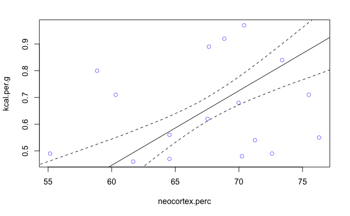

```r
lines(mp.seq, mu.PI[1, ], lty = 2)
lines(mp.seq, mu.PI[2, ], lty = 2)
```

## When adding variables hurts

### Multicollinearity

This is a simulation predicting an individual’s height using the l ength of his or her legs as predictor variables.

```r
N <- 100 # number of individuals
height <- rnorm(N, 10, 2) # sim total height of each
leg_prop <- runif(N, 0.4, 0.5)
leg_left <- leg_prop * height + rnorm(N, 0, 0.02) # sim left leg as proportion + error
leg_right <- leg_prop * height + rnorm(N, 0, 0.02) # sim right leg as proportion + error
d <- data.frame(height, leg_left, leg_right) # combine into data frame
# fit a model
m5.8 <- map(
  alist(height ~ dnorm(mu, sigma),
        mu <- a + bl * leg_left + br * leg_right,
        a ~ dnorm(10, 100),
        bl ~ dnorm(2, 10),
        br ~ dnorm(2, 10),
        sigma ~ dunif(0, 10)),
  data = d
)
precis(m5.8)
```

|  | Mean | StdDev | 5.5% | 94.5% |
| --- | --- | --- | --- | --- |
| a | 0.79 | 0.33 | 0.26 | 1.32 |
| bl | 2.67 | 1.94 | -0.42 | 5.77 |
| br | -0.64 | 1.94 | -3.75 | 2.47 |
| sigma | 0.63 | 0.04 | 0.56 | 0.70 |

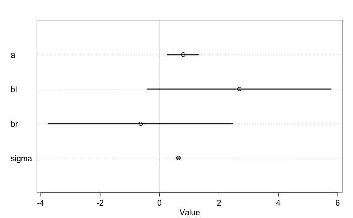

```r
plot(precis(m5.8))
```

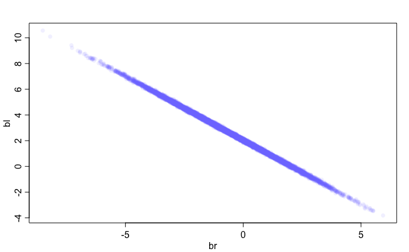

```r
post <- extract.samples(m5.8)
plot(bl ~ br, post, col = col.alpha(rangi2, 0.1), pch = 16)
```

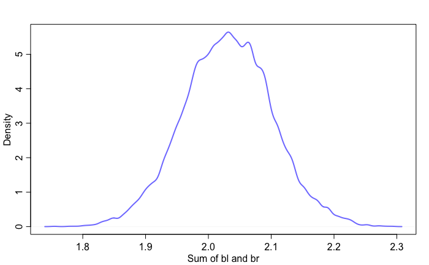

```r
# plotting the posterior sum
sum_blbr <- post$bl + post$br
dens(sum_blbr, col = rangi2, lwd = 2, xlab = "Sum of bl and br")
```

Fitting a model with only one of these predictors will produce almost the same posterior mean:

```r
# fit a model
m5.9 <- map(
  alist(height ~ dnorm(mu, sigma),
        mu <- a + bl * leg_left,
        a ~ dnorm(10, 100),
        bl ~ dnorm(2, 10),
        sigma ~ dunif(0, 10)),
  data = d
)
precis(m5.9)
```

|  | Mean | StdDev | 5.5% | 94.5% |
| --- | --- | --- | --- | --- |
| a | 0.77 | 0.33 | 0.25 | 1.30 |
| bl | 2.03 | 0.07 | 1.92 | 2.15 |
| sigma | 0.63 | 0.04 | 0.56 | 0.70 |

Back to the milk data

```r
library(rethinking)
data(milk)
d <- milk
# k.cal.per.g regressed on perc.fat
m5.10 <- map(
  alist(kcal.per.g ~ dnorm(mu, sigma),
        mu <- a + bf * perc.fat,
        a ~ dnorm(0.6, 10),
        bf ~ dnorm(0, 1),
        sigma ~ dunif(0, 10)),
  data = d
)
# kcal.per.g regressed on perc.lactose
m5.11 <- map(
  alist(kcal.per.g ~ dnorm(mu, sigma),
        mu <- a + bl * perc.lactose,
        a ~ dnorm(0.6, 10),
        bl ~ dnorm(0, 1),
        sigma ~ dunif(0, 10)),
  data = d
)
precis(m5.10, digits = 3)
```

|  | Mean | StdDev | 5.5% | 94.5% |
| --- | --- | --- | --- | --- |
| a | 0.301 | 0.036 | 0.244 | 0.358 |
| bf | 0.010 | 0.001 | 0.008 | 0.012 |
| sigma | 0.073 | 0.010 | 0.058 | 0.089 |

```r
precis(m5.11, digits = 3)
```

|  | Mean | StdDev | 5.5% | 94.5% |
| --- | --- | --- | --- | --- |
| a | 1.166 | 0.043 | 1.098 | 1.235 |
| bl | -0.011 | 0.001 | -0.012 | -0.009 |
| sigma | 0.062 | 0.008 | 0.049 | 0.075 |

```r
# now including both
m5.12 <- map(
  alist(kcal.per.g ~ dnorm(mu, sigma),
        mu <- a + bf * perc.fat + bl * perc.lactose,
        a ~ dnorm(0.6, 10),
        bf ~ dnorm(0, 1),
        bl ~ dnorm(0, 1),
        sigma ~ dunif(0, 10)),
  data = d
)
precis(m5.12, digits = 3)
```

|  | Mean | StdDev | 5.5% | 94.5% |
| --- | --- | --- | --- | --- |
| a | 1.007 | 0.200 | 0.688 | 1.327 |
| bf | 0.002 | 0.002 | -0.002 | 0.006 |
| bl | -0.009 | 0.002 | -0.013 | -0.005 |
| sigma | 0.061 | 0.008 | 0.048 | 0.074 |

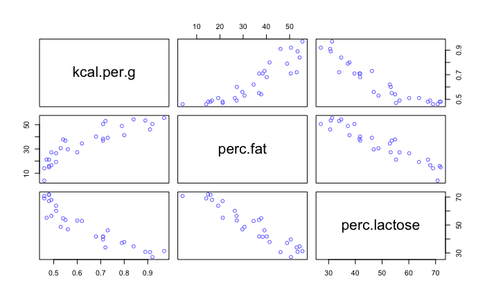

```r
pairs(~ kcal.per.g + perc.fat + perc.lactose, data = d, col = rangi2)
```

```r
cor(d$perc.fat, d$perc.lactose)
```

```
[1] -0.9416373
```

### Post-treatment bias

SUppose we want to know the difference in growth under different antifungal soil treatments, because fungus on the plants tends to reduce their growth.

```r
# number of plants
N <- 100
# simulate initial heights
h0 <- rnorm(N, 10, 2)
# assign treatments and simulate fungus and growth
treatment <- rep(0:1, each = N / 2)
fungus <- rbinom(N, size = 1, prob = 0.5 - treatment * 0.4)
h1 <- h0 + rnorm(N, 5 - 3 * fungus)
# compose a clean data frame
d <- data.frame(h0 = h0, h1 = h1, treatment = treatment, fungus = fungus)
# fit model
m5.13 <- map(
  alist(h1 ~ dnorm(mu, sigma),
        mu <- a + bh * h0 + bt * treatment + bf * fungus,
        a ~ dnorm(0, 100),
        c(bh, bt, bf) ~ dnorm(0, 10),
        sigma ~ dunif(0, 10)),
  data = d
)
precis(m5.13)
```

|  | Mean | StdDev | 5.5% | 94.5% |
| --- | --- | --- | --- | --- |
| a | 5.13 | 0.57 | 4.21 | 6.05 |
| bh | 0.97 | 0.06 | 0.88 | 1.06 |
| bt | 0.23 | 0.22 | -0.12 | 0.59 |
| bf | -2.80 | 0.24 | -3.18 | -2.42 |
| sigma | 1.02 | 0.07 | 0.91 | 1.14 |

We know that the treament is important so what is happening is that fungus is mostly a consequence of treatment. Thus, this model is really asking, “once we already know whether or not a plant developed fungus, does the soil treatment matter?” What we really want to know is the impact of treatment on growth:

```r
# fit model
m5.14 <- map(
  alist(h1 ~ dnorm(mu, sigma),
        mu <- a + bh * h0 + bt * treatment,
        a ~ dnorm(0, 100),
        c(bh, bt) ~ dnorm(0, 10),
        sigma ~ dunif(0, 10)),
  data = d
)
precis(m5.14)
```

|  | Mean | StdDev | 5.5% | 94.5% |
| --- | --- | --- | --- | --- |
| a | 4.26 | 0.88 | 2.85 | 5.66 |
| bh | 0.91 | 0.09 | 0.78 | 1.05 |
| bt | 1.30 | 0.32 | 0.79 | 1.80 |
| sigma | 1.58 | 0.11 | 1.40 | 1.75 |

## Categorical variables

### Binary categories

```r
data(Howell1)
d <- Howell1
str(d)
```

```
'data.frame':   544 obs. of  4 variables:
 $ height: num  152 140 137 157 145 ...
 $ weight: num  47.8 36.5 31.9 53 41.3 ...
 $ age   : num  63 63 65 41 51 35 32 27 19 54 ...
 $ male  : int  1 0 0 1 0 1 0 1 0 1 ...
```

```r
# fit model
m5.15 <- map(
  alist(height ~ dnorm(mu, sigma),
        mu <- a + bm * male,
        a ~ dnorm(178, 100),
        bm ~ dnorm(0, 10),
        sigma ~ dunif(0, 50)),
  data = d
)
precis(m5.15)
```

|  | Mean | StdDev | 5.5% | 94.5% |
| --- | --- | --- | --- | --- |
| a | 134.83 | 1.59 | 132.29 | 137.38 |
| bm | 7.28 | 2.28 | 3.63 | 10.93 |
| sigma | 27.31 | 0.83 | 25.99 | 28.63 |

```r
# posterior of a and bm
post <- extract.samples(m5.15)
mu.male <- post$a + post$bm
PI(mu.male)
```

```
      5%      94%
139.4363 144.8238
```

#### Many categories

```r
data(milk)
d <- milk
unique(d$clade)
```

```
[1] Strepsirrhine    New World Monkey Old World Monkey Ape
Levels: Ape New World Monkey Old World Monkey Strepsirrhine
```

```r
# create categories
(d$clade.NWM <- ifelse(d$clade == "New World Monkey", 1, 0))
```

```
 [1] 0 0 0 0 0 1 1 1 1 1 1 1 1 1 0 0 0 0 0 0 0 0 0 0 0 0 0 0 0
```

```r
d$clade.OWM <- ifelse(d$clade == "Old World Monkey", 1, 0)
d$clade.S <- ifelse(d$clade == "Strepsirrhine", 1, 0)
# fit the model
m5.16 <- map(
  alist(kcal.per.g ~ dnorm(mu, sigma),
        mu <- a + b.NWM * clade.NWM + b.OWM * clade.OWM + b.S * clade.S,
        a ~ dnorm(0.6, 10),
        b.NWM ~ dnorm(0, 1),
        b.OWM ~ dnorm(0, 1),
        b.S ~ dnorm(0, 1),
        sigma ~ dunif(0, 10)),
  data = d
)
precis(m5.16)
```

|  | Mean | StdDev | 5.5% | 94.5% |
| --- | --- | --- | --- | --- |
| a | 0.55 | 0.04 | 0.49 | 0.61 |
| b.NWM | 0.17 | 0.05 | 0.08 | 0.25 |
| b.OWM | 0.24 | 0.06 | 0.15 | 0.34 |
| b.S | -0.04 | 0.06 | -0.14 | 0.06 |
| sigma | 0.11 | 0.02 | 0.09 | 0.14 |

To get posterior distributions of the average milk energy in each category, use samples:

```r
# sample posterior
post <- extract.samples(m5.16)
# compute averages for each category
mu.ape <- post$a
mu.NWM <- post$a + post$b.NWM
mu.OWM <- post$a + post$b.OWM
mu.S <- post$a + post$b.S
# summarize using precis
precis(data.frame(mu.ape, mu.NWM, mu.OWM, mu.S))
```

|  | Mean | StdDev | \|0.89 | 0.89\| |
| --- | --- | --- | --- | --- |
| mu.ape | 0.55 | 0.04 | 0.49 | 0.61 |
| mu.NWM | 0.71 | 0.04 | 0.65 | 0.77 |
| mu.OWM | 0.79 | 0.05 | 0.71 | 0.86 |
| mu.S | 0.51 | 0.05 | 0.42 | 0.59 |

What if we wanted to know the difference between the two monkey groups? We just subtract the estimated means to get a difference:

```r
diff.NWM.OWM <- mu.NWM - mu.OWM
quantile(diff.NWM.OWM, probs = c(0.025, 0.5, 0.975))
```

```
       2.5%         50%       97.5%
-0.19338700 -0.07244251  0.04438848
```